# QTM 151 - Quiz 2

## Try to submit as an HTML file

Print your name below

```python
# Write your answer here
print("Ryan Kim")
```

```
Ryan Kim
```

This quiz is open book

- You can use the lecture notes
- You will get partial credit for attempting the questions
- To get full credit, the code should run as intended
- You should NOT communicate with other students

Print the following message:

"I will abide by Emory's code of conduct"

```python
# Write your answer here:
print("I will abide by Emory's code of conduct")
```

```
I will abide by Emory's code of conduct
```

Import the libraries "numpy", "matplotlib.pyplot",  
"pandas", "statsmodels.api" and "statsmodels.formula.api"

```python
# Write your answer here
import pandas as pd
import numpy as np
import matplotlib.pyplot as plt
import statsmodels.api as sm
import statsmodels.formula.api as smf
```

Read the dataset "data_quiz/fifa23_players_basic.csv"

- It's a dataset on professional soccer players
- Rows correspond to players (18,539)
- Columns contain attributes of players (32)
- Try to view the dataset before starting

to get a sense of its content

```python
# Write your own code
fifa = pd.read_csv("data_quiz/fifa23_players_basic.csv")
fifa
```

|  | Unnamed: 0 | Known As | Full Name | Overall | Potential | Value(in Euro) | Positions Played | Best Position | Nationality | Image Link | ... | Preferred Foot | Weak Foot Rating | Skill Moves | International Reputation | National Team Name | National Team Image Link | National Team Position | National Team Jersey Number | Attacking Work Rate | Defensive Work Rate |
| --- | --- | --- | --- | --- | --- | --- | --- | --- | --- | --- | --- | --- | --- | --- | --- | --- | --- | --- | --- | --- | --- |
| 0 | 0 | L. Messi | Lionel Messi | 91 | 91 | 54000000 | RW | CAM | Argentina | https://cdn.sofifa.net/players/158/023/23_60.png | ... | Left | 4 | 4 | 5 | Argentina | https://cdn.sofifa.net/flags/ar.png | RW | 10 | Low | Low |
| 1 | 1 | K. Benzema | Karim Benzema | 91 | 91 | 64000000 | CF,ST | CF | France | https://cdn.sofifa.net/players/165/153/23_60.png | ... | Right | 4 | 4 | 4 | France | https://cdn.sofifa.net/flags/fr.png | ST | 19 | Medium | Medium |
| 2 | 2 | R. Lewandowski | Robert Lewandowski | 91 | 91 | 84000000 | ST | ST | Poland | https://cdn.sofifa.net/players/188/545/23_60.png | ... | Right | 4 | 4 | 5 | Poland | https://cdn.sofifa.net/flags/pl.png | ST | 9 | High | Medium |
| 3 | 3 | K. De Bruyne | Kevin De Bruyne | 91 | 91 | 107500000 | CM,CAM | CM | Belgium | https://cdn.sofifa.net/players/192/985/23_60.png | ... | Right | 5 | 4 | 4 | Belgium | https://cdn.sofifa.net/flags/be.png | RF | 7 | High | High |
| 4 | 4 | K. Mbappé | Kylian Mbappé | 91 | 95 | 190500000 | ST,LW | ST | France | https://cdn.sofifa.net/players/231/747/23_60.png | ... | Right | 4 | 5 | 4 | France | https://cdn.sofifa.net/flags/fr.png | ST | 10 | High | Low |
| ... | ... | ... | ... | ... | ... | ... | ... | ... | ... | ... | ... | ... | ... | ... | ... | ... | ... | ... | ... | ... | ... |
| 18534 | 18534 | D. Collins | Darren Collins | 47 | 56 | 110000 | ST,RM | CAM | Republic of Ireland | https://cdn.sofifa.net/players/243/725/23_60.png | ... | Right | 3 | 2 | 1 | - | - | - | - | Medium | Medium |
| 18535 | 18535 | Yang Dejiang | Dejiang Yang | 47 | 57 | 90000 | CDM | CDM | China PR | https://cdn.sofifa.net/players/261/933/23_60.png | ... | Right | 3 | 2 | 1 | - | - | - | - | Medium | Medium |
| 18536 | 18536 | L. Mullan | Liam Mullan | 47 | 67 | 130000 | CM | RM | Northern Ireland | https://cdn.sofifa.net/players/267/823/23_60.png | ... | Right | 3 | 2 | 1 | - | - | - | - | High | Medium |
| 18537 | 18537 | D. McCallion | Daithí McCallion | 47 | 61 | 100000 | CB | CB | Republic of Ireland | https://cdn.sofifa.net/players/267/824/23_60.png | ... | Right | 3 | 2 | 1 | - | - | - | - | Medium | Medium |
| 18538 | 18538 | N. Rabha | Nabin Rabha | 47 | 50 | 60000 | LB | LB | India | https://cdn.sofifa.net/players/261/424/23_60.png | ... | Left | 3 | 2 | 1 | - | - | - | - | Medium | Medium |

18539 rows × 33 columns

(a) Use queries + global variables

- Subset the players whose value of the column "On Loan" is "YES"

and store it in a new dataset

- How many players are on loan?

HINT: Remember that there is a special syntax for  
when the column names have spaces (see Lecture 10)  
and when the value is a string.  
Reference the column as `` `On Loan` `` inside .query()

```python
# Write your own code
x = "YES"
fifaloaned = fifa.query("`On Loan` == @x")
numloanplayers = len(fifaloaned)
numloanplayers
```

```
1229
```

(b) Create a function and apply it to a column

Step 1:

- Define a function with a parameter "Overall"
- If "Overall > 90", classification = "Top Performer"
- If "Overall <= 90", classification = "Non Top-Performer"
- The function returns "classification"

Step 2:

- Extract the column "Overall" in the dataset

(be carefeful to write the "O" capitalized)

- Create a new variable called "player_classification"

to assign each player to the correct classification

HINT: Use the ".apply()" function

```python
# Write your own code
def fifa90 (Overall):
    if Overall > 90 :
        classification = "Top Performer"
    else:
        classification = "Non Top-Performer"
    return classification


fifa["player_classification"] = fifa["Overall"].apply(fifa90)
fifa
```

|  | Unnamed: 0 | Known As | Full Name | Overall | Potential | Value(in Euro) | Positions Played | Best Position | Nationality | Image Link | ... | Weak Foot Rating | Skill Moves | International Reputation | National Team Name | National Team Image Link | National Team Position | National Team Jersey Number | Attacking Work Rate | Defensive Work Rate | player_classification |
| --- | --- | --- | --- | --- | --- | --- | --- | --- | --- | --- | --- | --- | --- | --- | --- | --- | --- | --- | --- | --- | --- |
| 0 | 0 | L. Messi | Lionel Messi | 91 | 91 | 54000000 | RW | CAM | Argentina | https://cdn.sofifa.net/players/158/023/23_60.png | ... | 4 | 4 | 5 | Argentina | https://cdn.sofifa.net/flags/ar.png | RW | 10 | Low | Low | Top Performer |
| 1 | 1 | K. Benzema | Karim Benzema | 91 | 91 | 64000000 | CF,ST | CF | France | https://cdn.sofifa.net/players/165/153/23_60.png | ... | 4 | 4 | 4 | France | https://cdn.sofifa.net/flags/fr.png | ST | 19 | Medium | Medium | Top Performer |
| 2 | 2 | R. Lewandowski | Robert Lewandowski | 91 | 91 | 84000000 | ST | ST | Poland | https://cdn.sofifa.net/players/188/545/23_60.png | ... | 4 | 4 | 5 | Poland | https://cdn.sofifa.net/flags/pl.png | ST | 9 | High | Medium | Top Performer |
| 3 | 3 | K. De Bruyne | Kevin De Bruyne | 91 | 91 | 107500000 | CM,CAM | CM | Belgium | https://cdn.sofifa.net/players/192/985/23_60.png | ... | 5 | 4 | 4 | Belgium | https://cdn.sofifa.net/flags/be.png | RF | 7 | High | High | Top Performer |
| 4 | 4 | K. Mbappé | Kylian Mbappé | 91 | 95 | 190500000 | ST,LW | ST | France | https://cdn.sofifa.net/players/231/747/23_60.png | ... | 4 | 5 | 4 | France | https://cdn.sofifa.net/flags/fr.png | ST | 10 | High | Low | Top Performer |
| ... | ... | ... | ... | ... | ... | ... | ... | ... | ... | ... | ... | ... | ... | ... | ... | ... | ... | ... | ... | ... | ... |
| 18534 | 18534 | D. Collins | Darren Collins | 47 | 56 | 110000 | ST,RM | CAM | Republic of Ireland | https://cdn.sofifa.net/players/243/725/23_60.png | ... | 3 | 2 | 1 | - | - | - | - | Medium | Medium | Non Top-Performer |
| 18535 | 18535 | Yang Dejiang | Dejiang Yang | 47 | 57 | 90000 | CDM | CDM | China PR | https://cdn.sofifa.net/players/261/933/23_60.png | ... | 3 | 2 | 1 | - | - | - | - | Medium | Medium | Non Top-Performer |
| 18536 | 18536 | L. Mullan | Liam Mullan | 47 | 67 | 130000 | CM | RM | Northern Ireland | https://cdn.sofifa.net/players/267/823/23_60.png | ... | 3 | 2 | 1 | - | - | - | - | High | Medium | Non Top-Performer |
| 18537 | 18537 | D. McCallion | Daithí McCallion | 47 | 61 | 100000 | CB | CB | Republic of Ireland | https://cdn.sofifa.net/players/267/824/23_60.png | ... | 3 | 2 | 1 | - | - | - | - | Medium | Medium | Non Top-Performer |
| 18538 | 18538 | N. Rabha | Nabin Rabha | 47 | 50 | 60000 | LB | LB | India | https://cdn.sofifa.net/players/261/424/23_60.png | ... | 3 | 2 | 1 | - | - | - | - | Medium | Medium | Non Top-Performer |

18539 rows × 34 columns

(c) Use sorting + ".iloc[]"

The varable "Joined On" shows the date in which each player joined FIFA

- Use ".sort_values()" to order the "Joined On" column

from earlier data to later date

- Get a subset with the 6 players in the dataset

who joined FIFA earliest

- From this subset, display the year in which they joined

by displaying the column "Joined On"

```python
# Write your own code
fifajoin = fifa.sort_values(by = "`Joined On`", ascending = True)
fifajoin.iloc[0:6]
display(fifa["`Joined On`"])
```

[output not shown]

(d) Regression function

- Run a regression of "Potential" (left-hand side) on "Age" (right-hand side)
- What are the values of the coefficients?

[HINT: Use the commands `smf.ols()` and `.fit()` and `.params`  
from Lecture 11 ]

```python
# Write your own code
x = fifa["Age"]
y = fifa["Potential"]
model = smf.ols(formula = 'y ~ x', data = fifa)
results = model.fit()
b_list = results.params
print(b_list)
```

```
Intercept    79.752454
x            -0.346103
dtype: float64
```

(e) Split a dataset into subsets

- Store the total number of rows of the dataset in a variable called `n`
- Create a new variable called `random_var` drawn from a

uniform distribution between 0 and 1 with size `n`

- Use .query() to subset all observations with `random_var <0.5`.

store it in a new dataset called "data0"

- Use .query() to subset all observations with `random_var >= 0.5`.

store it in a new dataset called "data1"

[HINT: See Lecture 2 for how to generate a uniform random variable]

```python
# Write your own code
n = len(fifa)
random_var = np.random.uniform(0,1,size = n)
data0 = fifa.query("@random_var < 0.5")
data1 = fifa.query("@random_var >= 0.5")
```

(f) Create two overlapping histogram plots

- This question requires the two datasets you created in (e)
- Display the distribution of "Age" for "data0" and "data1" using

`plt.hist()`

- You will need to label the axes, and the title
- To get full points, plot the histograms with the option `alpha = 0.5`, e.g.

`plt.hist(x = ..., alpha = 0.5)`  
Make sure to substitute the corresponding "x" vector instead of `...`  
(The alpha option sets the transparency of the histogram )

Note: The goal of this question is to illustrate that random  
assignment produces very similar distributions between two groups

```
No artists with labels found to put in legend.  Note that artists whose label start with an underscore are ignored when legend() is called with no argument.
```

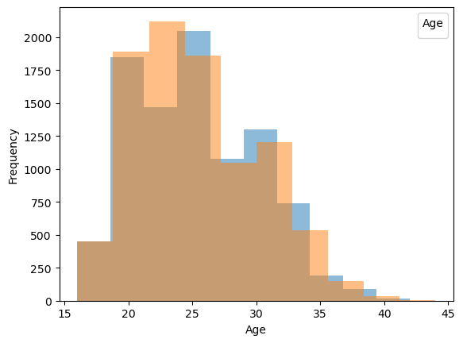

```python
plt.hist(x = data0["Age"], alpha = 0.5, bins = 10)
plt.hist(x = data1["Age"], alpha = 0.5, bins = 10)
plt.xlabel("Age")
plt.ylabel("Frequency")

plt.legend(
           title  = "Age")
plt.show()
```